# Assignment 2

```r
library(caTools)
library(rpart)
library(randomForest)
library(rattle)
```

## Prediction the letter B

> To warm up, start by predicting whether or not the letter is “B.” First, create a new variable called IsB in your dataset, which takes value “Yes” if the letter is B, and “No” if the letter is not B. Then randomly split your dataset into a training set and a testing set, putting 50% of the data in each set.

The `with` function creates a new logical object which takes value `TRUE` if the letter in the dataset is B and `FALSE` otherwise. This variable is added to the original dataset using the `cbind` function. After that the dataset is splitted into a train and a test set of the same dimension since the split ratio condition is set to a half.

```r
Letters <- read.csv("D:/Università/Data Science/Decision Model/Assignment2/Letters.csv")
isB = with(Letters, Letter=="B")
Letters = cbind(Letters, isB)

set.seed(1234)
spl = sample.split(Letters$isB, SplitRatio = 0.50)
trainB = subset(Letters, spl==TRUE)
testB = subset(Letters, spl==FALSE)
```

> Before building models, let us consider a baseline method that always predicts the most frequent outcome, which is “not B.” What is the accuracy of this baseline method on the test set?

First of all we need to check which is the most frequent outcome on the train dataset; in order to do that, a simple table function can be used to determinate if the `TRUE` values are the most frequent or viceversa.

```r
table(trainB$isB)
```

```
##
## FALSE  TRUE
##  1175   383
```

From the output is clear that most of the outcomes are`FALSE`, indeed with a baseline method that always predict the most frequent outcome, all the $1558$ observation in the test set will be predicted as `FALSE`. To check which is the accuracy of this method it’s required to run once again the table function but this time on the test dataset: as it was just said, this method will predict all the observations as false, so the accuracy will be the number of `FALSE` values in the test set (which are the correct predictions) divided by the number of rows.

```r
baselinePredB = table(testB$isB)
baselineAccB = baselinePredB[[1]] / nrow(testB)
baselineAccB
```

```
## [1] 0.754172
```

> Build a CART tree to predict whether or not a letter is a B, using the training set to build your model. Remember to not use the variable Letter as one of the independent variables in the model, as this is related to what we are trying to predict! Select reasonable parameter values for the model, and justify your parameter choices. What is the accuracy of this CART model on the test set?

```r
Formula = isB ~ Xbox + Ybox + Width + Height + Onpix + Xbar + Ybar + X2bar + Y2bar + XYbar + X2Ybar + XY2bar + Xedge + XedgeYcor + Yedge + YedgeXcor

minbucket = seq(5, 20, by=1)
accVect = NULL

for(i in minbucket){
  TreeB = rpart(formula = Formula, method="class", data=trainB, control=rpart.control(minbucket=i))
  predictionB = predict(TreeB, newdata=testB, type="class")
  matrixB = table(testB$isB, predictionB)
  treeBAcc = (matrixB[1] + matrixB[4]) / nrow(testB)
  accVect = c(accVect, treeBAcc)
  }
```

To decide which is the better parameter for the CART model, we start with taking in consideration only the `minbucket`, a parameter that determinates the minimum number of observations in terminal nodes. First of all a formula variable is created containing all the variables of the dataset but Letter and isB (which is the object of the prediction). A tree is created on training dataset and consequentely a prediction is made using that model on test set. A confusion matrix is computed with the `table` function between the original data inside the test set and its predictions. The output is a 2x2 matrix and to compute the accuracy is just necessary to sum the elements on the main diagonal and divide by the number of observations. Since the model can have pretty different results depending on which parameters are chosen, this operation is repeated several times with a different number of minimum observations in terminal node. To achive this, a vector was created using the `seq` funciont; in particular this vector contains every number from $5$ to $20$ and at each step each number is passed as parameter in the Tree’s function. The lower bound was set to $5$ since a lower value would have meant that basically some “ad hoc” splits for the observations, meanwhile the upper limit of $20$ is a reasonable choice considering the dimension of the dataset. An empty vector is created to store of the accuracies. To evaluate which is the optimal parameter to choose, which maximize the accuracy, a plot is a useful tool for this task. According to the description of the package, the `cp` parameter is $0.01$ and `minsplit` is three times the minibucket parameter.

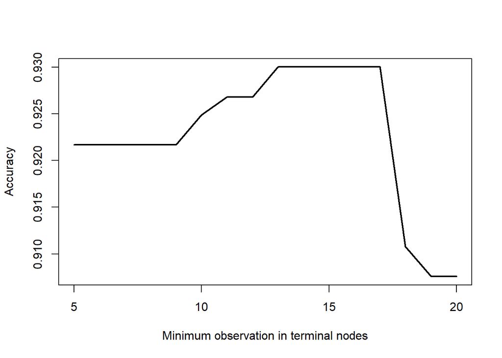

```r
plot(x=minbucket, y=accVect, col=1, lwd=2, xlab='Minimum observation in terminal nodes', ylab='Accuracy', type="l")
```

The plot looks pretty weird, it does not increase or decrease monotonically, but it shows how accuracy depends on which parameter of `minbucket` is set. An evolution of the cycle is implemented down below: in this case there are two `for` cycles the outer changes the value of the complexity parameter and the inner one is the same as before.

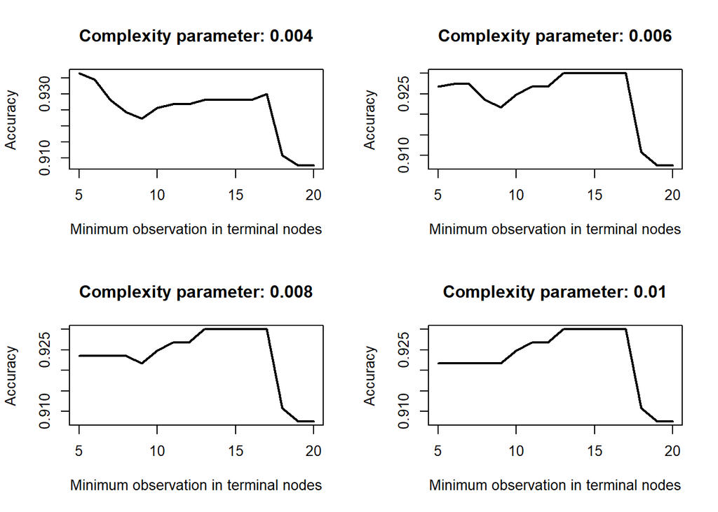

```r
par(mfrow=c(2,2))
cplist = seq(0.004, 0.01, by=0.002)

for(j in cplist){
  accVect = NULL

  for(i in minbucket){

    TreeB = rpart(formula = Formula, method="class", data=trainB, control=rpart.control(minbucket=i, cp=j))
    predictionB = predict(TreeB, newdata=testB, type="class")
    matrixB = table(testB$isB, predictionB)
    treeBAcc = (matrixB[1] + matrixB[4]) / nrow(testB)
    accVect = c(accVect, treeBAcc)

  }
  plot(x=minbucket, y=accVect, col=1, lwd=2, xlab='Minimum observation in terminal nodes', ylab='Accuracy', type="l", main=paste('Complexity parameter:', j))
}
```

The command `par(mfrow=c(2,2))` allows to plot 4 graph in once for a better comparison. On the bottom right there’s the original plot showed before, in this one the accuracy is lower the the two others on the first line, and it’s a quite obvious results since the tree accepts some splits that permit to gain even a smaller improvment for accuracy than the two on the bottom. Since the dataset is not big and the computational time is not an issue, the selected tree have as parameters $`minbucket`=5$ and $`cp`=0.004$, and its accuracy is

```r
TreeB = rpart(formula = Formula, method="class", data=trainB, control=rpart.control(minbucket=5, cp=0.004))
predictionB = predict(TreeB, newdata=testB, type="class")
matrixB = table(testB$isB, predictionB)
(matrixB[1] + matrixB[4]) / nrow(testB)
```

```
## [1] 0.936457
```

The best tree looks like this:

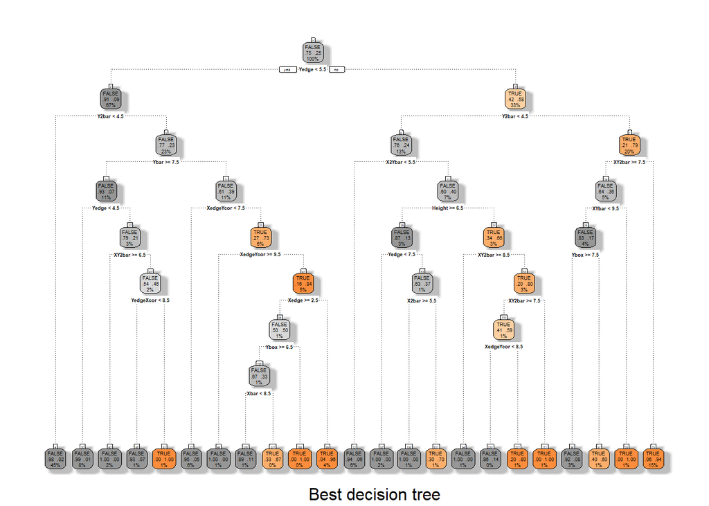

```r
fancyRpartPlot(TreeB, palettes=c("Greys", "Oranges"), sub = "Best decision tree")
```

> Now, build a random forest model to predict whether or not the letter is a B. Again, select reasonable parameter values for the model, and justify your parameter choices. What is the accuracy of the model on the test set?

Once again a double `for` cycle is implemented to check which set of parameters gives the best accuracy.

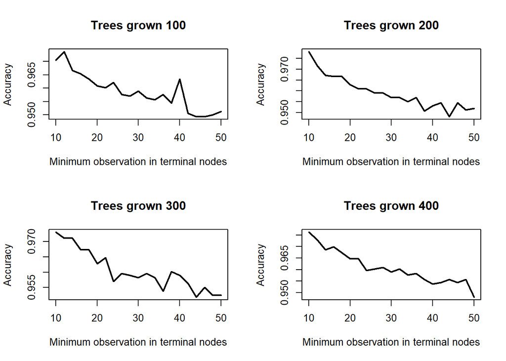

```r
set.seed(1234)
par(mfrow=c(2,2))

trainB$isB = as.factor(trainB$isB)

ntreeList = seq(100, 400, by=100)
nodesizeList = seq(10, 50, by=2)

for(i in ntreeList){
  accVect = NULL

  for (j in nodesizeList){
    RFB = randomForest(formula=Formula, data=trainB, ntree=i, nodesize=j)
    predictionBRF = predict(RFB, newdata=testB)
    matrixBRF =table(testB$isB, predictionBRF)
    accBRF = (matrixBRF[1] + matrixBRF[4]) / nrow(testB)
    accVect = c(accVect, accBRF)
  }

  plot(x=nodesizeList, y=accVect, col=1, lwd=2, xlab='Minimum observation in terminal nodes', ylab='Accuracy', type="l", main=paste('Trees grown', i))
}
```

Overall the accuracy of the random forest is higher, and this is an expected result. Again a lower `nodesize` means a better accuracy with basically the same value with $10$ observations at minimum in the final nodes while computing $200$ and $400$ trees. In these two cases we check the exact value of the accuracy

```r
tempVect = c(200, 400)

for(val in  tempVect){
  RFB = randomForest(formula=Formula, data=trainB, ntree=val, nodesize=10)
  predictionBRF = predict(RFB, newdata=testB)
  matrixBRF = table(testB$isB, predictionBRF)
  print((matrixBRF[1] + matrixBRF[4]) / nrow(testB))
}
```

```
## [1] 0.9730424
## [1] 0.9762516
```

The accuracy achived with $400$ is the highest. The only possible drawback in choosing $400$ instead of $200$ trees is about the computational time, but with a fixed value of `nodesize` it takes just a few seconds and indeed it’s not a problem at all.

> Compare the accuracy of your CART and Random Forest models. Which one performs better? For this application, do you think interpretability or accuracy is more important?

Obviously with the random forest we get a better accuracy since its the combination of more trees and not a single one. The accuracy is more important than the interpretability for two reasons: the first one is that only someone who’s really into this field could understand why `Yedge` is the first variable to split and what does it mean. The second reason is that this data were manually distorted for the classification task, hence reaching the maximum accuracy should be the main goal.

## Building a more general predictor

> In a multi-class classification problem, a simple baseline model is to predict the most frequent class of all of the options for every observation. For this problem, what does the baseline method predict, and what is the baseline accuracy on the testing set? Do you think this simple baseline method is a useful benchmark for this problem? Why or why not?

The code is like the previous one made for the letter B in the first request.

```r
set.seed(1234)
spl = sample.split(Letters$Letter, SplitRatio = 0.50)
train = subset(Letters, spl==TRUE)
test = subset(Letters, spl==FALSE)

table(train$Letter)
```

```
##
##   A   B   P   R
## 394 383 402 379
```

Basically all the letters are almost evenly equal.

```r
baselinePred = table(test$Letter)
baselineAcc = baselinePred[[3]] /nrow(test)
baselineAcc
```

```
## [1] 0.2573813
```

The accuracy with a baseline method is just $0.2574$ which is way lower than the one achived by the first baseline method with just the letter “B” and definitely not suitble for a prediction. Usually the baseline method is never a good choice, there’s always some, even easy and simple method, which is better than that one; in this particular case since the letter’s ratio is almost the same, probably it’s the worst possible method.

> Now build a classification tree to predict Letter, using the training set to build your model. (Remember not to use the variable **IsB** in the model, as this is related to what we are trying to predict!) Select reasonable parameter values and justify your parameter choices. What is the test set accuracy of your CART model? (HINT: When you are computing the test set accuracy using a classification matrix, you want to add everything on the main diagonal and divide by the total number of observations in the test set.)

```r
newFormula = Letter ~ Xbox + Ybox + Width + Height + Onpix + Xbar + Ybar + X2bar + Y2bar + XYbar + X2Ybar + XY2bar + Xedge + XedgeYcor + Yedge + YedgeXcor

Tree = rpart(formula = newFormula, method="class", data=train, control=rpart.control(minbucket=5, cp=0.004))
predictionTree = predict(Tree, newdata=test, type="class")
matrixTree = table(test$Letter, predictionTree)
matrixTree
```

```
##    predictionTree
##       A   B   P   R
##   A 365  10   0  20
##   B   4 330  11  38
##   P   0  17 384   0
##   R   5  28   7 339
```

```r
TreeAcc = sum(diag(matrixTree))/ nrow(test)
TreeAcc
```

```
## [1] 0.9101412
```

The first tree built is the best obtained in the previous step. At first glance it looks a very good model: even if now the task is to predict 4 different outcomes and not only “B or not B”, its accuracy is still very high. To check for other possible, maybe better, models, the same `for` cycles are run once again.

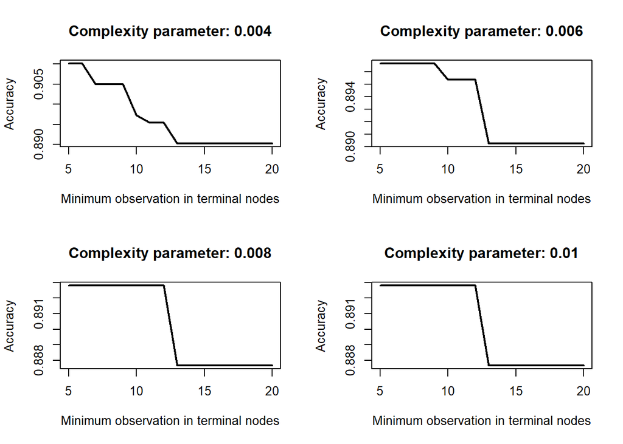

```r
par(mfrow=c(2,2))
cplist = seq(0.004, 0.01, by=0.002)

for(j in cplist){
  accVect = NULL

  for(i in minbucket){

    Tree = rpart(formula = newFormula, method="class", data=train, control=rpart.control(minbucket=i, cp=j))
    predictionTree = predict(Tree, newdata=test, type="class")
    matrixTree = table(test$Letter, predictionTree)
    TreeAcc = sum(diag(matrixTree))/ nrow(test)
    accVect = c(accVect, TreeAcc)

  }
  plot(x=minbucket, y=accVect, col=1, lwd=2, xlab='Minimum observation in terminal nodes', ylab='Accuracy', type="l", main=paste('Complexity parameter:', j))
}
```

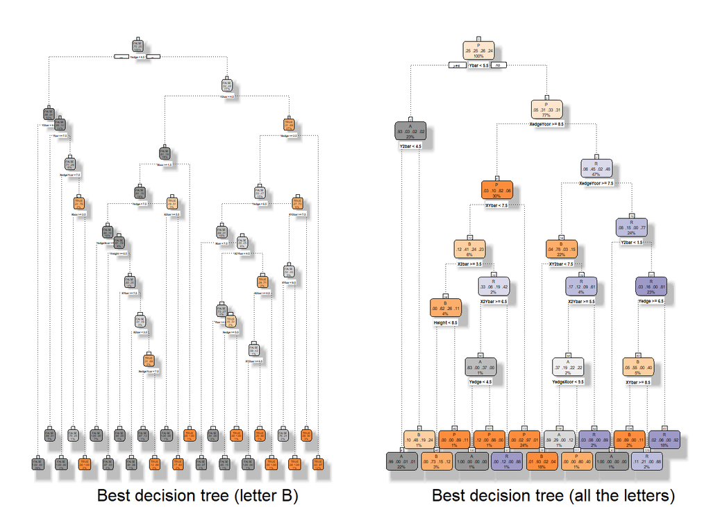

```r
par(mfrow=c(1,2))

BTree = rpart(formula=Formula, method="class", data=train, control=rpart.control(minbucket=5, cp=0.004))
Tree = rpart(formula=newFormula, method="class", data=train, control=rpart.control(minbucket=5, cp=0.004))
fancyRpartPlot(BTree, palettes=c("Greys", "Oranges"), sub = "Best decision tree (letter B)")
fancyRpartPlot(Tree, palettes=c("Greys", "Oranges"), sub = "Best decision tree (all the letters)")
```

Since it’s not very clear from the plot which are the most important variables, we can check their importance with the following commands.

```r
BTree$variable.importance
```

```
##     Yedge     Xedge     Y2bar     X2bar YedgeXcor     Onpix XedgeYcor
## 185.20295 167.09537 159.29761 110.73519 109.02758  99.95262  93.79315
##      Xbox      Ybox     Width    XY2bar      Ybar      Xbar    Height
##  66.55603  58.53740  53.96755  51.24606  43.25169  41.75839  35.38154
##     XYbar    X2Ybar
##  33.00425  26.41812
```

```r
Tree$variable.importance
```

```
##       Ybar  XedgeYcor     X2Ybar     XY2bar      Yedge      Xedge
## 471.199182 412.565853 320.095067 306.531854 244.315632 209.094801
##      Y2bar      XYbar  YedgeXcor      X2bar       Xbar      Onpix
## 184.729739 167.066222 146.542886 138.312712 104.016473  19.660565
##       Ybox       Xbox     Height      Width
##  18.434122  16.327138  11.788451   1.448926
```

It’s worth to underlight that even if the two trees are the same in terms of parameters, on two different tasks the order of the most important variables is not the same.

> Now, build a random forest model to predict **Letter**, using the training data - again, do not forget to remove the **IsB** variable. What is the test set accuracy of your random forest model?

```r
RF = randomForest(formula=newFormula, data=train, ntree=400, nodesize=10)
predictionRF = predict(RF, newdata=test)
matrixRF = table(test$Letter, predictionRF)
print((sum(diag(matrixRF))) / nrow(test))
```

```
## [1] 0.9736842
```

The accuracy looks great with the best RF obtained in the previous task, let’s what happen this time with some changes in the parameters

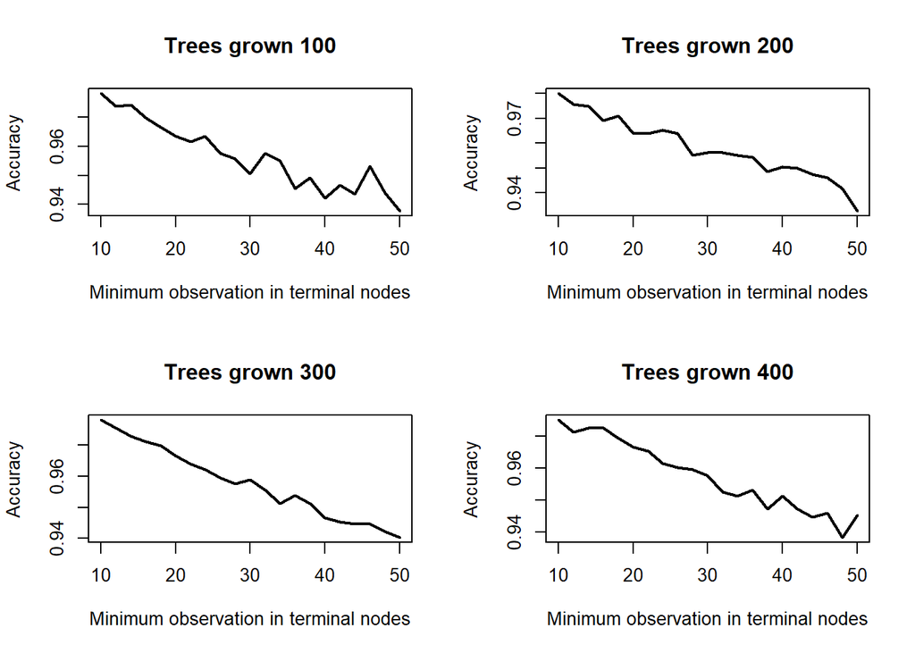

```r
set.seed(1234)
par(mfrow=c(2,2))

for(i in ntreeList){
  accVect = NULL

  for (j in nodesizeList){
    RF = randomForest(formula=newFormula, data=train, ntree=i, nodesize=j)
    predictionRF = predict(RF, newdata=test)
    matrixRF = table(test$Letter, predictionRF)
    accRF = (sum(diag(matrixRF))) / nrow(test)
    accVect = c(accVect, accRF)
  }

  plot(x=nodesizeList, y=accVect, col=1, lwd=2, xlab='Minimum observation in terminal nodes', ylab='Accuracy', type="l", main=paste('Trees grown', i))
}
```

```r
accVect = NULL
for (j in nodesizeList){
  RF = randomForest(formula=newFormula, data=trainB, ntree=200, nodesize=j)
  predictionRF = predict(RF, newdata=testB)
  matrixRF = table(testB$Letter, predictionRF)
  accRF = (sum(diag(matrixRF))) / nrow(testB)
  accVect = c(accVect, accRF)
}

bestRF = cbind.data.frame(nodesizeList, accVect)
bestRF[order(-accVect),]
```

```
##    nodesizeList   accVect
## 1            10 0.9659820
## 2            12 0.9646983
## 3            14 0.9646983
## 6            20 0.9634146
## 5            18 0.9608472
## 8            24 0.9608472
## 4            16 0.9602054
## 7            22 0.9589217
## 10           28 0.9582798
## 9            26 0.9563543
## 11           30 0.9550706
## 12           32 0.9531451
## 17           42 0.9525032
## 14           36 0.9512195
## 16           40 0.9512195
## 13           34 0.9499358
## 15           38 0.9486521
## 18           44 0.9480103
## 19           46 0.9422336
## 20           48 0.9415918
## 21           50 0.9364570
```

> Compare the accuracy of your CART and Random Forest models for this problem. Which one would you recommend for this problem? Is your choice different from the model you recommended for letter B?